# Regressão Logística - Spaceship Titanic

Alexandre Nordin, Cândido Silva e Daniela Bragança

2022-07-09

# Importação da base de dados

```r
dados = read.csv('train.csv', sep=',')
test = read.csv('test.csv', sep=',')

head(dados)
```

```
##   PassengerId HomePlanet CryoSleep Cabin   Destination Age   VIP RoomService
## 1     0001_01     Europa     False B/0/P   TRAPPIST-1e  39 False           0
## 2     0002_01      Earth     False F/0/S   TRAPPIST-1e  24 False         109
## 3     0003_01     Europa     False A/0/S   TRAPPIST-1e  58  True          43
## 4     0003_02     Europa     False A/0/S   TRAPPIST-1e  33 False           0
## 5     0004_01      Earth     False F/1/S   TRAPPIST-1e  16 False         303
## 6     0005_01      Earth     False F/0/P PSO J318.5-22  44 False           0
##   FoodCourt ShoppingMall  Spa VRDeck              Name Transported
## 1         0            0    0      0   Maham Ofracculy       False
## 2         9           25  549     44      Juanna Vines        True
## 3      3576            0 6715     49     Altark Susent       False
## 4      1283          371 3329    193      Solam Susent       False
## 5        70          151  565      2 Willy Santantines        True
## 6       483            0  291      0 Sandie Hinetthews        True
```

# Análise Exploratória

## Verificação de nulos

```r
summary(dados)
```

```
##  PassengerId         HomePlanet         CryoSleep            Cabin
##  Length:8693        Length:8693        Length:8693        Length:8693
##  Class :character   Class :character   Class :character   Class :character
##  Mode  :character   Mode  :character   Mode  :character   Mode  :character
##
##
##
##
##  Destination             Age            VIP             RoomService
##  Length:8693        Min.   : 0.00   Length:8693        Min.   :    0.0
##  Class :character   1st Qu.:19.00   Class :character   1st Qu.:    0.0
##  Mode  :character   Median :27.00   Mode  :character   Median :    0.0
##                     Mean   :28.83                      Mean   :  224.7
##                     3rd Qu.:38.00                      3rd Qu.:   47.0
##                     Max.   :79.00                      Max.   :14327.0
##                     NA's   :179                        NA's   :181
##    FoodCourt        ShoppingMall          Spa              VRDeck
##  Min.   :    0.0   Min.   :    0.0   Min.   :    0.0   Min.   :    0.0
##  1st Qu.:    0.0   1st Qu.:    0.0   1st Qu.:    0.0   1st Qu.:    0.0
##  Median :    0.0   Median :    0.0   Median :    0.0   Median :    0.0
##  Mean   :  458.1   Mean   :  173.7   Mean   :  311.1   Mean   :  304.9
##  3rd Qu.:   76.0   3rd Qu.:   27.0   3rd Qu.:   59.0   3rd Qu.:   46.0
##  Max.   :29813.0   Max.   :23492.0   Max.   :22408.0   Max.   :24133.0
##  NA's   :183       NA's   :208       NA's   :183       NA's   :188
##      Name           Transported
##  Length:8693        Length:8693
##  Class :character   Class :character
##  Mode  :character   Mode  :character
##
##
##
##
```

```r
dadosComNulos = dados[!complete.cases(dados),]
head(dadosComNulos)
```

```
##    PassengerId HomePlanet CryoSleep Cabin   Destination Age   VIP RoomService
## 8      0006_02      Earth      True G/0/S   TRAPPIST-1e  28 False           0
## 11     0008_02     Europa      True B/1/P   TRAPPIST-1e  34 False           0
## 17     0014_01       Mars     False F/3/P   55 Cancri e  27 False        1286
## 24     0020_03      Earth      True E/0/S   55 Cancri e  29 False           0
## 26     0020_05      Earth      True E/0/S PSO J318.5-22   1 False          NA
## 29     0024_01     Europa      True C/2/S   TRAPPIST-1e  62 False           0
##    FoodCourt ShoppingMall Spa VRDeck               Name Transported
## 8          0            0   0     NA Candra Jacostaffey        True
## 11         0           NA   0      0     Altardr Flatic        True
## 17       122           NA   0      0        Flats Eccle       False
## 24         0           NA   0      0 Mollen Mcfaddennon       False
## 26         0            0   0      0    Mael Brantuarez       False
## 29         0           NA   0      0    Penton Fullided        True
```

8693 observações, da quais 1073 contém dados nulos. Não serão removidas para análise individual.

## Análise Exploratória - PassengerId

```r
# PassengerId - A unique Id for each passenger. Each Id takes the form gggg_pp where gggg indicates a group the passenger is travelling with and pp is their number within the group. People in a group are often family members, but not always.

summary(dados$PassengerId) # Campo de tipo character
```

```
##    Length     Class      Mode
##      8693 character character
```

```r
dupData = dados[duplicated(dados$PassengerId)]
dupData # não existem linhas duplicadas
```

```
## data frame with 0 columns and 8693 rows
```

```r
head(dados$PassengerId) # Verificado formato gggg_pp
```

```
## [1] "0001_01" "0002_01" "0003_01" "0003_02" "0004_01" "0005_01"
```

```r
# Separação dos campos
PassengerId_temp = dados$PassengerId %>% str_split(pattern="_", simplify=TRUE)
dados$PassengerId_Group = PassengerId_temp[, 1] %>% as.integer()
dados$PassengerId_Num = PassengerId_temp[, 2] %>% as.integer()

Test_PassengerId_temp = test$PassengerId %>% str_split(pattern="_", simplify=TRUE)
test$PassengerId_Group = Test_PassengerId_temp[, 1] %>% as.integer()
test$PassengerId_Num = Test_PassengerId_temp[, 2] %>% as.integer()

# PassengerId_Group
summary(dados$PassengerId_Group) # Valores inteiros variando de 1 a 9280
```

```
##    Min. 1st Qu.  Median    Mean 3rd Qu.    Max.
##       1    2319    4630    4633    6883    9280
```

```r
# PassengerId_Num
counts = table(dados$PassengerId_Num)
counts
```

```
##
##    1    2    3    4    5    6    7    8
## 6217 1412  571  231  128   75   46   13
```

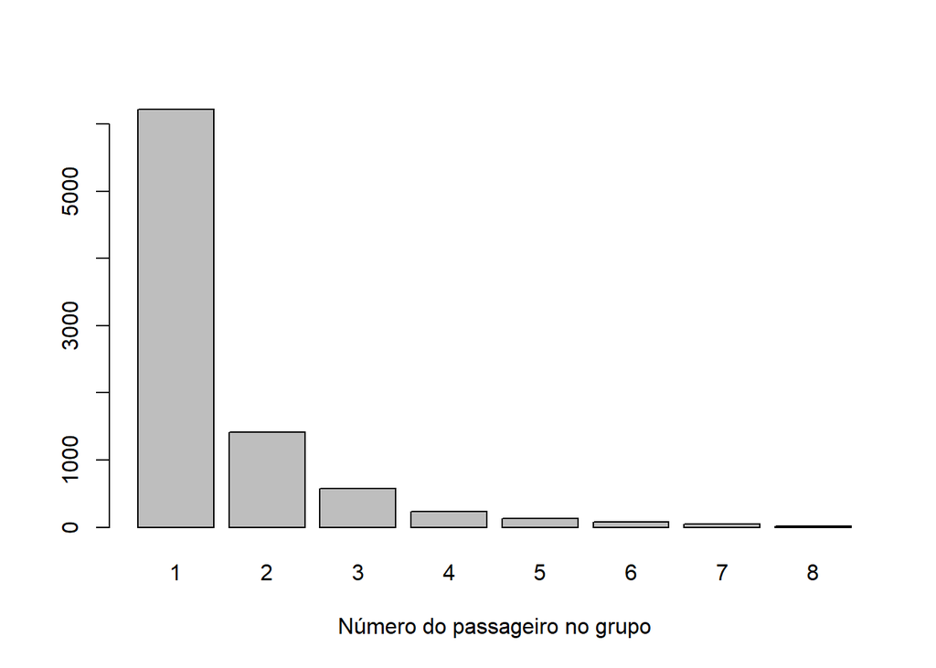

```r
barplot(counts, main = "", xlab="Número do passageiro no grupo")
```

```r
dados = dados[, !colnames(dados) %in% c("PassengerId")]
# dados = dados[, !colnames(dados) %in% c("PassengerId_Group")]
# test = test[, !colnames(test) %in% c("PassengerId_Group")]
```

PassengerId foi dividido em grupo e número, conforme explicada na documentação da base. O campo original foi dropado da base de treino, porém não pode ser dropado da base de teste, pois será usado na exportação. É possível perceber que os grupos são formados inicialmente com um componente.

## Análise Exploratória - HomePlanet

```r
# HomePlanet - The planet the passenger departed from, typically their planet of permanent residence.

summary(dados$HomePlanet) #Campo de tipo character
```

```
##    Length     Class      Mode
##      8693 character character
```

```r
head(dados$HomePlanet)
```

```
## [1] "Europa" "Earth"  "Europa" "Europa" "Earth"  "Earth"
```

```r
unique(dados$HomePlanet) # 4 valores possíveis: "Europa" "Earth"  "Mars" ""
```

```
## [1] "Europa" "Earth"  "Mars"   ""
```

```r
counts = table(dados$HomePlanet)
counts
```

```
##
##         Earth Europa   Mars
##    201   4602   2131   1759
```

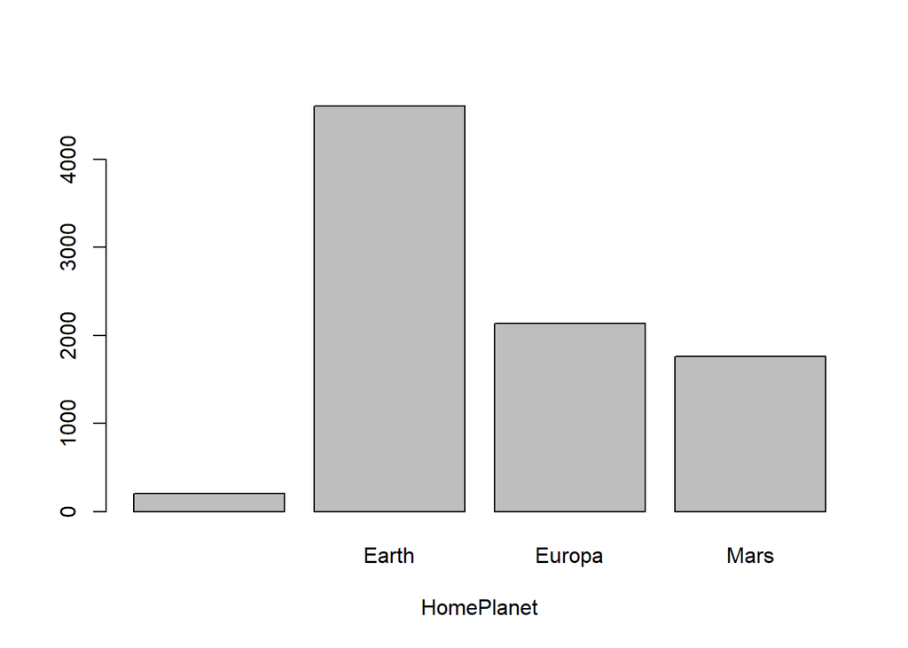

```r
barplot(counts, main="", xlab="HomePlanet")
```

```r
# Tratamento para que os passageiros sem anotação de planeta de origem sejam atribuídos ao mais frequente (Earth)
dados[dados$HomePlanet == "",]$HomePlanet =  "Earth"
test[test$HomePlanet == "",]$HomePlanet =  "Earth"

dados$HomePlanet = factor(dados$HomePlanet)

counts = table(dados$HomePlanet)
counts
```

```
##
##  Earth Europa   Mars
##   4803   2131   1759
```

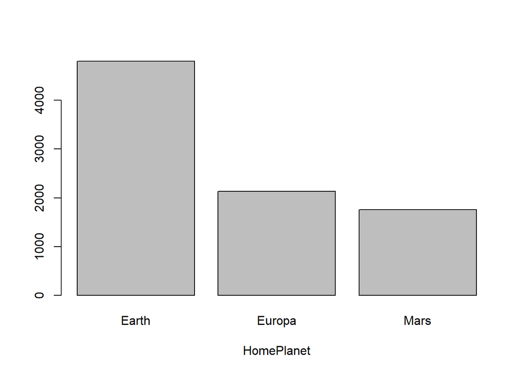

```r
barplot(counts, main="", xlab="HomePlanet")
```

201 registros sem planeta de origem, que foram substituídos pelo mais frequente (Earth). Devido ao número de opções e falta de hierarquia entre elas, será usado one-hot encoding.

## Análise Exploratória - CryoSleep

```r
# CryoSleep - Indicates whether the passenger elected to be put into suspended animation for the duration of the voyage. Passengers in cryosleep are confined to their cabins.

summary(dados$CryoSleep) # Campo de tipo character
```

```
##    Length     Class      Mode
##      8693 character character
```

```r
head(dados$CryoSleep)
```

```
## [1] "False" "False" "False" "False" "False" "False"
```

```r
unique(dados$CryoSleep) # 3 valores possíveis, "" "True" "False"
```

```
## [1] "False" "True"  ""
```

```r
counts = table(dados$CryoSleep)
counts
```

```
##
##       False  True
##   217  5439  3037
```

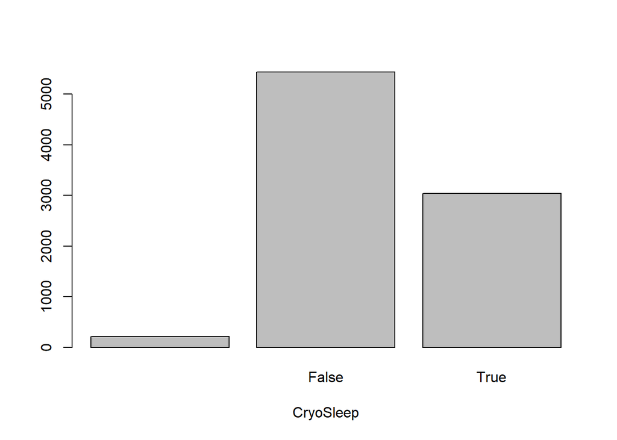

```r
barplot(counts, xlab="CryoSleep")
```

```r
# Convertendo valores para numérico e tratando os vazios
dados$CryoSleep = as.integer(dados$CryoSleep == "True")
test$CryoSleep = as.integer(test$CryoSleep == "True")

counts = table(dados$CryoSleep)
counts
```

```
##
##    0    1
## 5656 3037
```

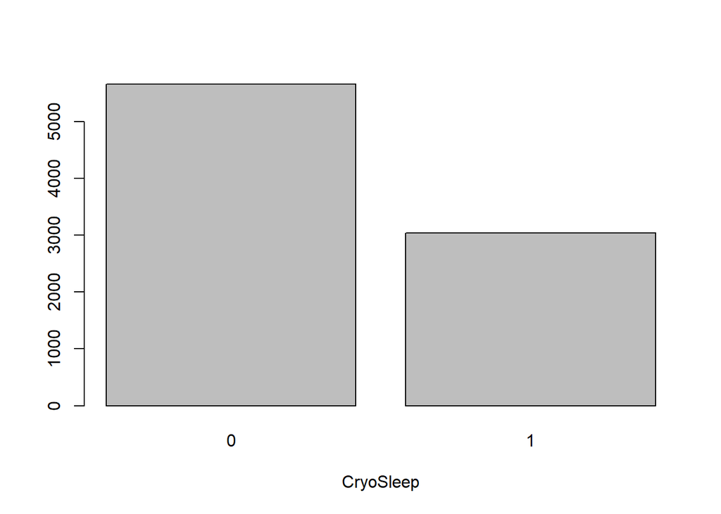

```r
barplot(counts, xlab="CryoSleep")
```

Considerando se tratar de um campo booleano, foi feito o tratamento para que os 217 campos nulos se tornem a classe prevalente (False) e sejam convertidos para 1 e 0.

## Análise Exploratória - Cabin

```r
# Cabin - The cabin number where the passenger is staying. Takes the form deck/num/side, where side can be either P for Port or S for Starboard.

summary(dados$Cabin) # Campo de tipo character
```

```
##    Length     Class      Mode
##      8693 character character
```

```r
head(dados$Cabin) # Verificada a estrutura do conteúdo
```

```
## [1] "B/0/P" "F/0/S" "A/0/S" "A/0/S" "F/1/S" "F/0/P"
```

```r
# Separação dos campos
cabin_temp = dados$Cabin %>% str_split(pattern="/", simplify=TRUE)
dados$Cabin_Deck = cabin_temp[, 1] %>% as.factor()
dados$Cabin_Num = cabin_temp[, 2] %>% as.integer()
dados$Cabin_Side = cabin_temp[, 3] %>% str_replace(pattern="P", replace="Port") %>% str_replace(pattern="S", replace="StarBoard") %>% as.factor()

Test_cabin_temp = test$Cabin %>% str_split(pattern="/", simplify=TRUE)
test$Cabin_Deck = Test_cabin_temp[, 1] %>% as.factor()
test$Cabin_Num = Test_cabin_temp[, 2] %>% as.integer()
test$Cabin_Side = Test_cabin_temp[, 3] %>% str_replace(pattern="P", replace="Port") %>% str_replace(pattern="S", replace="StarBoard") %>% as.factor()

# Valores possíveis: A B C D E F G T
counts = table(dados$Cabin_Deck)
counts
```

```
##
##         A    B    C    D    E    F    G    T
##  199  256  779  747  478  876 2794 2559    5
```

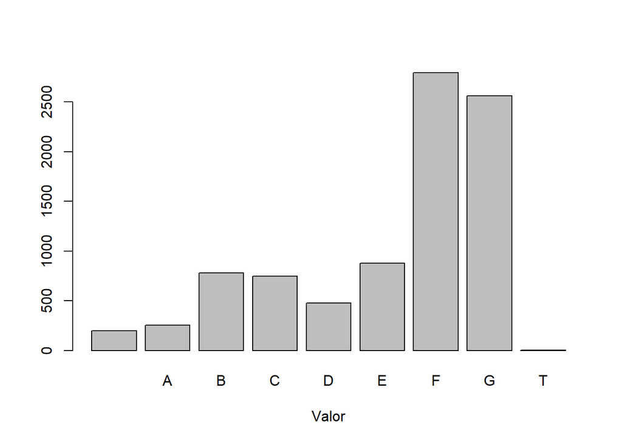

```r
barplot(counts, mais="Campo", xlab="Valor")
```

```r
# Números de 0 a 1894, com 199 nulos
summary(dados$Cabin_Num)
```

```
##    Min. 1st Qu.  Median    Mean 3rd Qu.    Max.    NA's
##     0.0   167.2   427.0   600.4   999.0  1894.0     199
```

```r
# Valores possíveis: "", Port e StarBoard
unique(dados$Cabin_Side)
```

```
## [1] Port      StarBoard
## Levels:  Port StarBoard
```

```r
counts = table(dados$Cabin_Side)
counts
```

```
##
##                Port StarBoard
##       199      4206      4288
```

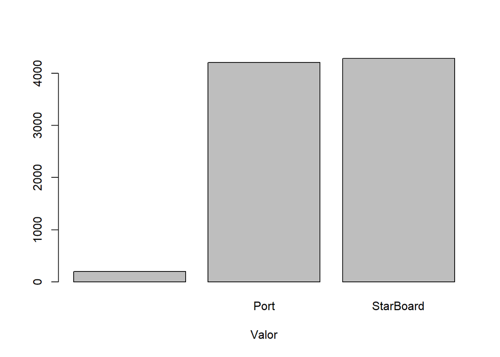

```r
barplot(counts, mais="Campo", xlab="Valor")
```

```r
#Drop do campo Cabin completo
dados = dados[, !colnames(dados) %in% c("Cabin")]
test = test[, !colnames(test) %in% c("Cabin")]
```

Foram mantidos os valores vazios (““).

## Análise Exploratória - Destination

```r
# Destination - The planet the passenger will be debarking to.

summary(dados$Destination) # Campo de tipo character
```

```
##    Length     Class      Mode
##      8693 character character
```

```r
head(dados$Destination)
```

```
## [1] "TRAPPIST-1e"   "TRAPPIST-1e"   "TRAPPIST-1e"   "TRAPPIST-1e"
## [5] "TRAPPIST-1e"   "PSO J318.5-22"
```

```r
unique(dados$Destination)
```

```
## [1] "TRAPPIST-1e"   "PSO J318.5-22" "55 Cancri e"   ""
```

```r
# Substituição dos valores por algo mais fácil de lidar
dados[dados$Destination == "PSO J318.5-22",]$Destination =  "P"
dados[dados$Destination == "55 Cancri e",]$Destination =  "C"
dados[dados$Destination == "TRAPPIST-1e",]$Destination =  "T"

test[test$Destination == "PSO J318.5-22",]$Destination =  "P"
test[test$Destination == "55 Cancri e",]$Destination =  "C"
test[test$Destination == "TRAPPIST-1e",]$Destination =  "T"

summary(dados$Destination)
```

```
##    Length     Class      Mode
##      8693 character character
```

```r
dados$Destination = factor(dados$Destination)

counts = table(dados$Destination)
counts
```

```
##
##         C    P    T
##  182 1800  796 5915
```

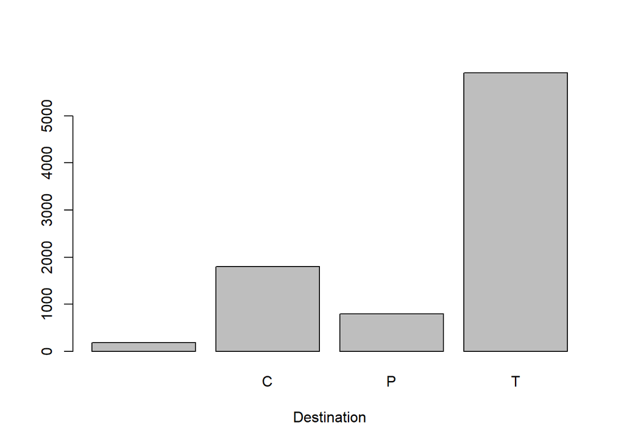

```r
barplot(counts, mais="", xlab="Destination")
```

```r
# Substituição dos destinos vazios pelo prevalente
dados[dados$Destination == "",]$Destination =  "T"
test[test$Destination == "",]$Destination =  "T"

dados$Destination = factor(dados$Destination)

counts = table(dados$Destination)
counts
```

```
##
##    C    P    T
## 1800  796 6097
```

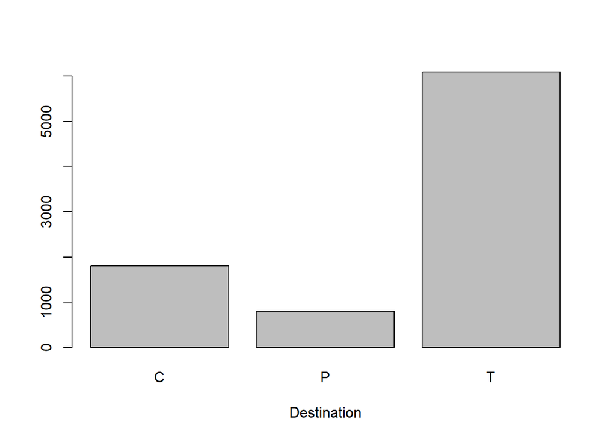

```r
barplot(counts, mais="", xlab="Destination")
```

São 3 planetas de destino, sendo que os registros vazios foram colocados no destino mais comum (“TRAPPIST-1e”).

## Análise Exploratória - Age

```r
# Age - The age of the passenger.

summary(dados$Age) # de 0 a 79, com 179 nulos
```

```
##    Min. 1st Qu.  Median    Mean 3rd Qu.    Max.    NA's
##    0.00   19.00   27.00   28.83   38.00   79.00     179
```

```r
head(dados$Age)
```

```
## [1] 39 24 58 33 16 44
```

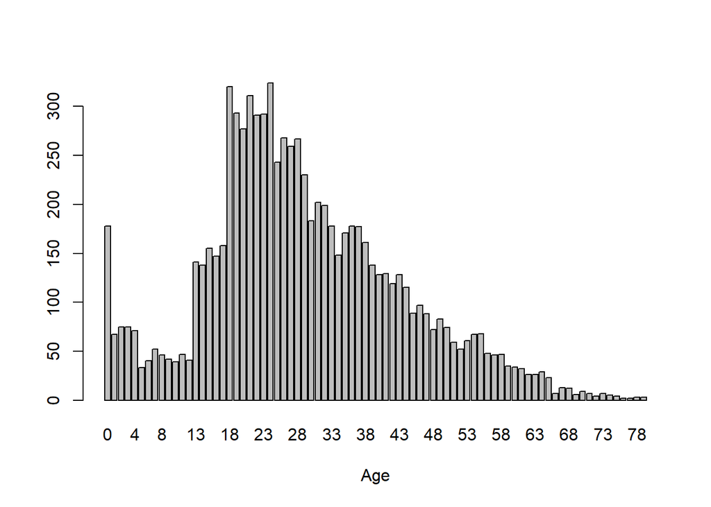

```r
counts = table(dados$Age)
barplot(counts, mais="", xlab="Age")
```

```r
# Substituição dos nulos pela média das idades
dados$Age = dados$Age %>% replace_na(mean(dados$Age, na.rm=TRUE))
test$Age = test$Age %>% replace_na(mean(test$Age, na.rm=TRUE))

summary(dados$Age) # de 0 a 79, sem nulos
```

```
##    Min. 1st Qu.  Median    Mean 3rd Qu.    Max.
##    0.00   20.00   27.00   28.83   37.00   79.00
```

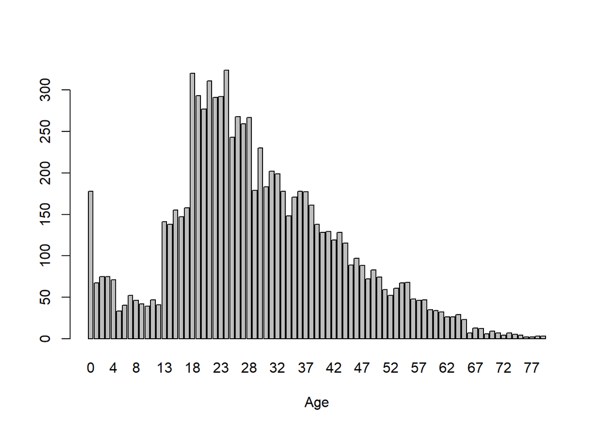

```r
counts = table(dados$Age)
barplot(counts, mais="", xlab="Age")
```

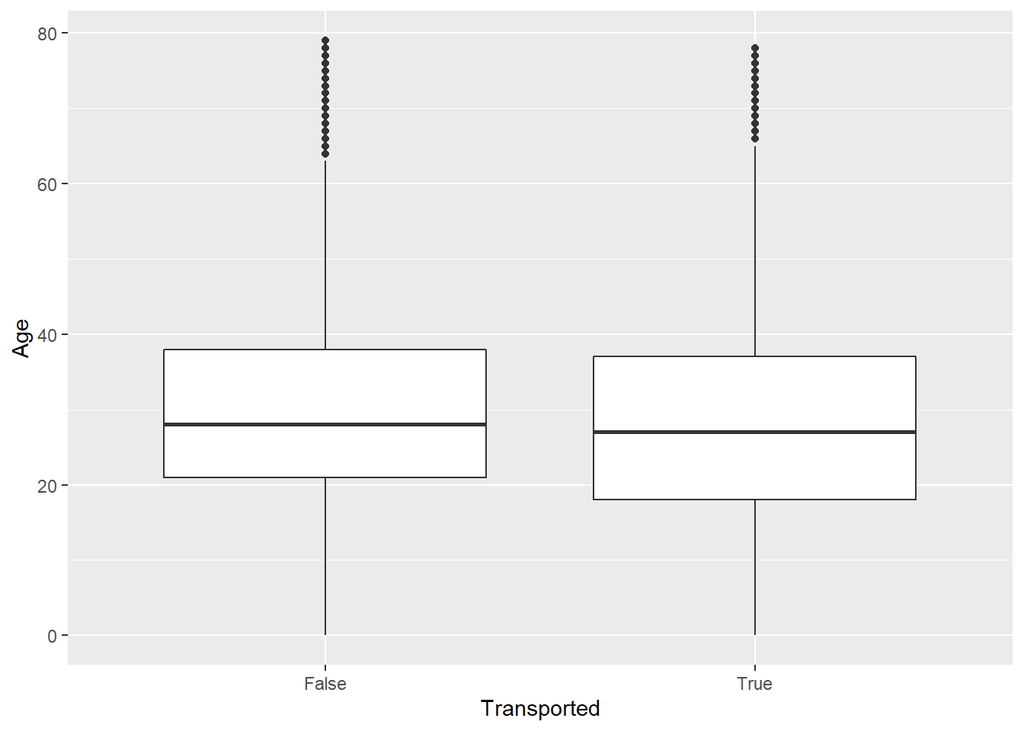

```r
ggplot(dados, aes(x=Transported, y=Age)) + geom_boxplot()
```

```r
#ggplot(dados, aes(x=Transported, y=Age, fill=Transported)) +
    #theme(legend.position="none") +
    #scale_fill_brewer(palette="Set1")
```

Para os campos nulos, foi utilizada a média dos demais valores. Importante notar que há muitos registros com idade 0. Pelo bloxpot, não há diferença significativa nas idades das duas classes.

## Análise Exploratória - VIP

```r
# VIP - Whether the passenger has paid for special VIP service during the voyage.

summary(dados$VIP)
```

```
##    Length     Class      Mode
##      8693 character character
```

```r
head(dados$VIP)
```

```
## [1] "False" "False" "True"  "False" "False" "False"
```

```r
unique(dados$VIP)
```

```
## [1] "False" "True"  ""
```

```r
counts = table(dados$VIP)
counts
```

```
##
##       False  True
##   203  8291   199
```

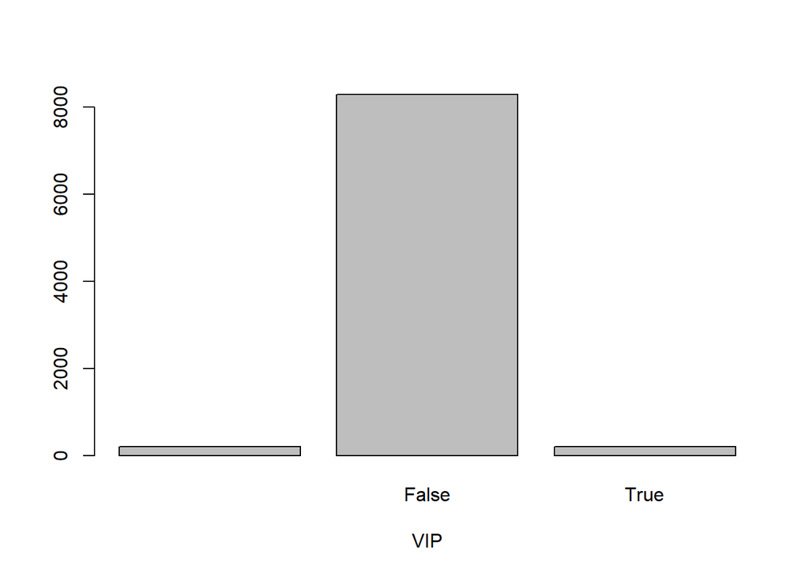

```r
barplot(counts, mais="", xlab="VIP")
```

```r
dados$VIP = as.integer(dados$VIP == "True")
test$VIP = as.integer(test$VIP == "True")

counts = table(dados$VIP)
counts
```

```
##
##    0    1
## 8494  199
```

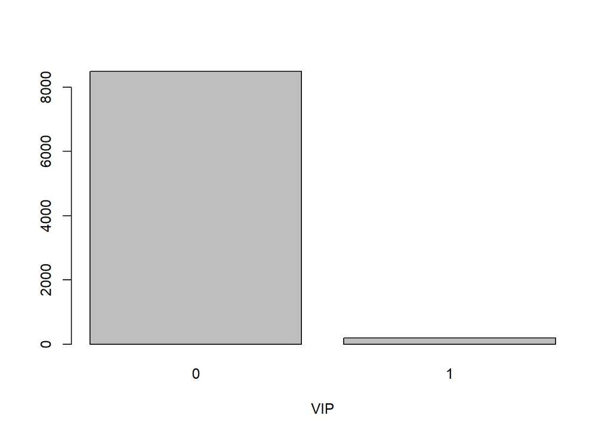

```r
barplot(counts, mais="", xlab="VIP")
```

Considerando a prevalência do False e o fato te existirem campos com valor vazio, foi feito o preenchimento.

## Análise Exploratória - RoomService

```r
# RoomService, FoodCourt, ShoppingMall, Spa, VRDeck - Amount the passenger has billed at each of the Spaceship Titanic's many luxury amenities.
summary(dados$RoomService) #Valor de 0 a 14327, com 181 nulos
```

```
##    Min. 1st Qu.  Median    Mean 3rd Qu.    Max.    NA's
##     0.0     0.0     0.0   224.7    47.0 14327.0     181
```

```r
head(dados$RoomService)
```

```
## [1]   0 109  43   0 303   0
```

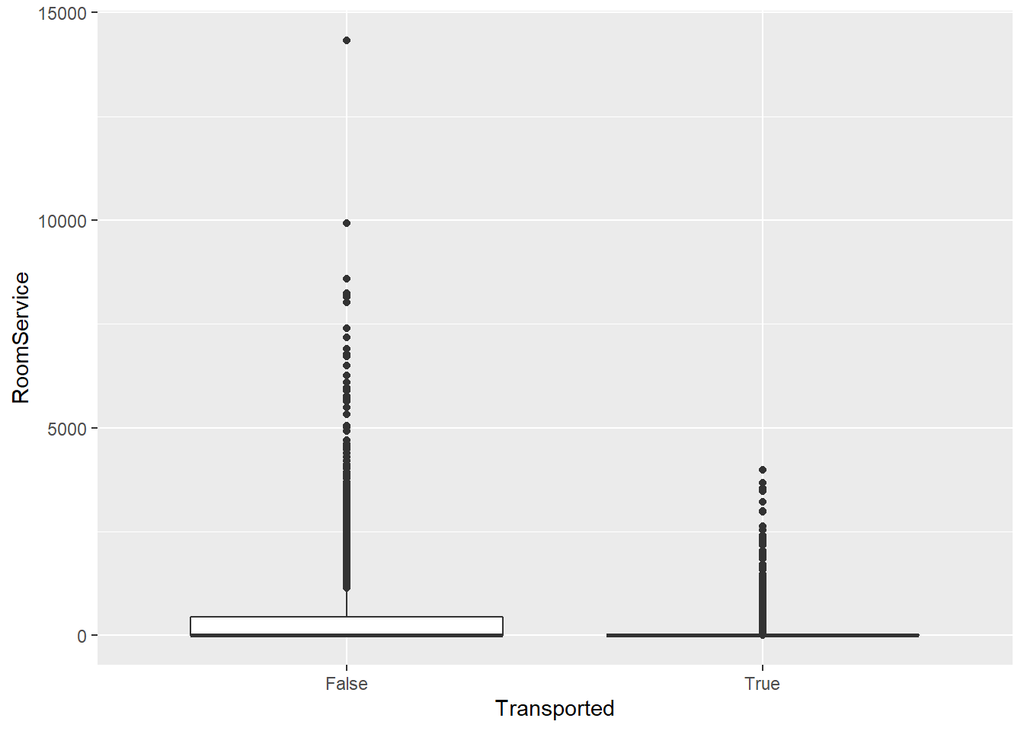

```r
# Substituição dos nulos por 0
dados$RoomService = dados$RoomService %>% replace_na(0)
test$RoomService = test$RoomService %>% replace_na(0)

ggplot(dados, aes(x=Transported, y=RoomService)) + geom_boxplot()
```

Feito o tratamento para valores nulos receberem 0.

## Análise Exploratória - FoodCourt

```r
# RoomService, FoodCourt, ShoppingMall, Spa, VRDeck - Amount the passenger has billed at each of the Spaceship Titanic's many luxury amenities.
summary(dados$FoodCourt) # Valores de 0 a 29813, com 183 nulos
```

```
##    Min. 1st Qu.  Median    Mean 3rd Qu.    Max.    NA's
##     0.0     0.0     0.0   458.1    76.0 29813.0     183
```

```r
head(dados$FoodCourt)
```

```
## [1]    0    9 3576 1283   70  483
```

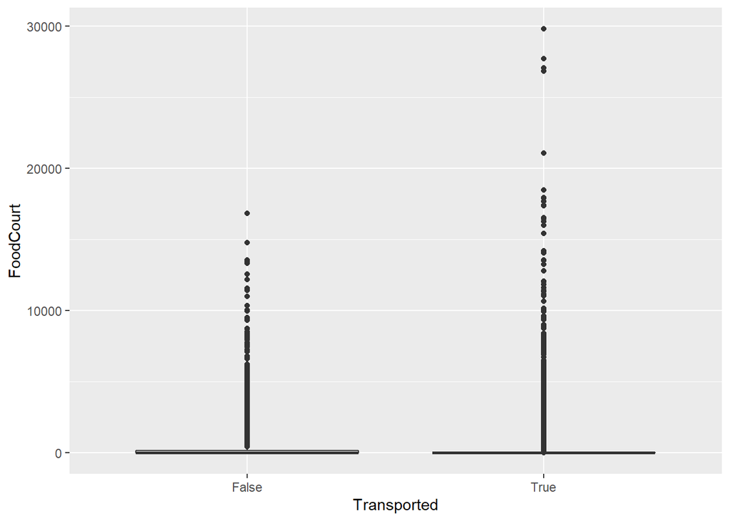

```r
# Substituição dos nulos por 0
dados$FoodCourt = dados$FoodCourt %>% replace_na(0)
test$FoodCourt = test$FoodCourt %>% replace_na(0)

ggplot(dados, aes(x=Transported, y=FoodCourt)) + geom_boxplot()
```

Feito o tratamento para valores nulos receberem 0.

## Análise Exploratória - ShoppingMall

```r
# RoomService, FoodCourt, ShoppingMall, Spa, VRDeck - Amount the passenger has billed at each of the Spaceship Titanic's many luxury amenities.
summary(dados$ShoppingMall) # Valores de 0 a 23492, com 208 nulos
```

```
##    Min. 1st Qu.  Median    Mean 3rd Qu.    Max.    NA's
##     0.0     0.0     0.0   173.7    27.0 23492.0     208
```

```r
head(dados$ShoppingMall)
```

```
## [1]   0  25   0 371 151   0
```

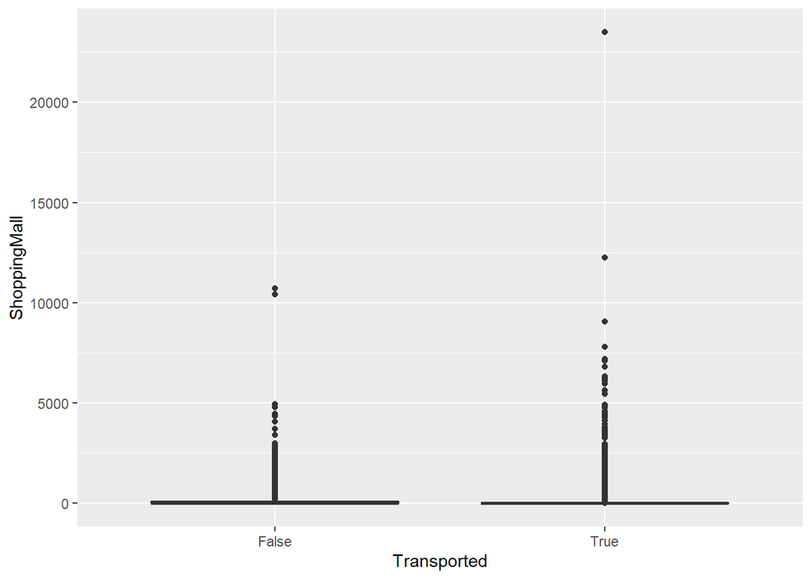

```r
# Substituição dos nulos por 0
dados$ShoppingMall = dados$ShoppingMall %>% replace_na(0)
test$ShoppingMall = test$ShoppingMall %>% replace_na(0)

ggplot(dados, aes(x=Transported, y=ShoppingMall)) + geom_boxplot()
```

Feito o tratamento para valores nulos receberem 0.

## Análise Exploratória - Spa

```r
summary(dados$Spa) # Valores de 0 a 22408, com 183 nulos
```

```
##    Min. 1st Qu.  Median    Mean 3rd Qu.    Max.    NA's
##     0.0     0.0     0.0   311.1    59.0 22408.0     183
```

```r
head(dados$Spa)
```

```
## [1]    0  549 6715 3329  565  291
```

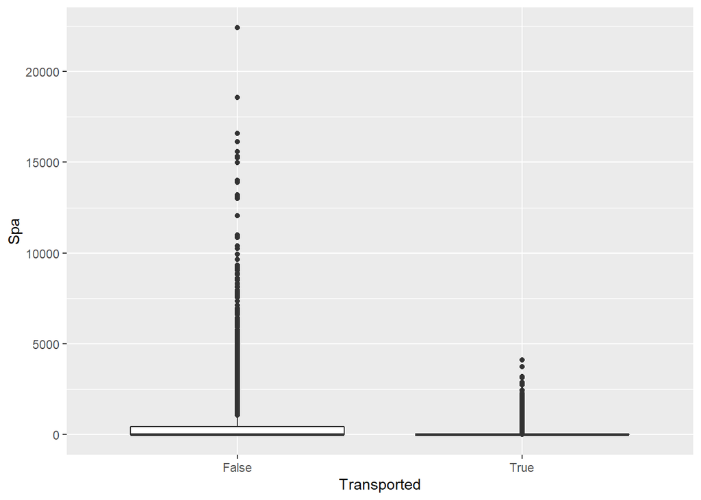

```r
# Substituição dos nulos por 0
dados$Spa = dados$Spa %>% replace_na(0)
test$Spa = test$Spa %>% replace_na(0)

ggplot(dados, aes(x=Transported, y=Spa)) + geom_boxplot()
```

Feito o tratamento para valores nulos receberem 0.

## Análise Exploratória - VRDeck

```r
# RoomService, FoodCourt, ShoppingMall, Spa, VRDeck - Amount the passenger has billed at each of the Spaceship Titanic's many luxury amenities.
summary(dados$VRDeck) # Valores de 0 a 22133, com 188 nulos
```

```
##    Min. 1st Qu.  Median    Mean 3rd Qu.    Max.    NA's
##     0.0     0.0     0.0   304.9    46.0 24133.0     188
```

```r
head(dados$VRDeck)
```

```
## [1]   0  44  49 193   2   0
```

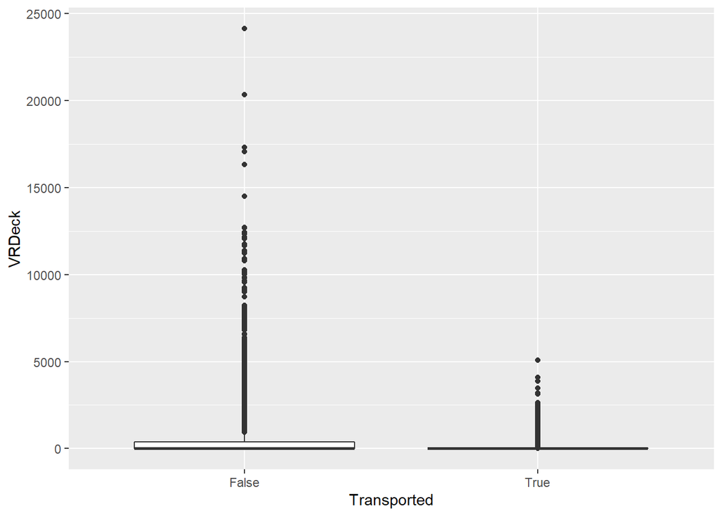

```r
# Substituição dos nulos por 0
dados$VRDeck = dados$VRDeck %>% replace_na(0)
test$VRDeck = test$VRDeck %>% replace_na(0)

ggplot(dados, aes(x=Transported, y=VRDeck)) + geom_boxplot()
```

Feito o tratamento para valores nulos receberem 0.

## Análise Exploratória - Name

```r
# Name - The first and last names of the passenger.
summary(dados$Name)  #Campo de tipo character
```

```
##    Length     Class      Mode
##      8693 character character
```

```r
head(dados$Name) # Os nomes são campos exclusivos de cada passageiro
```

```
## [1] "Maham Ofracculy"   "Juanna Vines"      "Altark Susent"
## [4] "Solam Susent"      "Willy Santantines" "Sandie Hinetthews"
```

```r
dados = dados[, !colnames(dados) %in% c("Name")]
test = test[, !colnames(test) %in% c("Name")]
```

Como o campo é exclusivo de cada passageiro (tal qual sua chave) e, a princípio, não dá para identificar padrões como sexo, esse campo foi eliminado em ambas as bases (treino e teste).

## Análise Exploratória - Transported

```r
# Transported - Whether the passenger was transported to another dimension. This is the target, the column you are trying to predict.

summary(dados$Transported)
```

```
##    Length     Class      Mode
##      8693 character character
```

```r
head(dados$Transported)
```

```
## [1] "False" "True"  "False" "False" "True"  "True"
```

```r
unique(dados$Transported)
```

```
## [1] "False" "True"
```

```r
counts = table(dados$Transported)
counts
```

```
##
## False  True
##  4315  4378
```

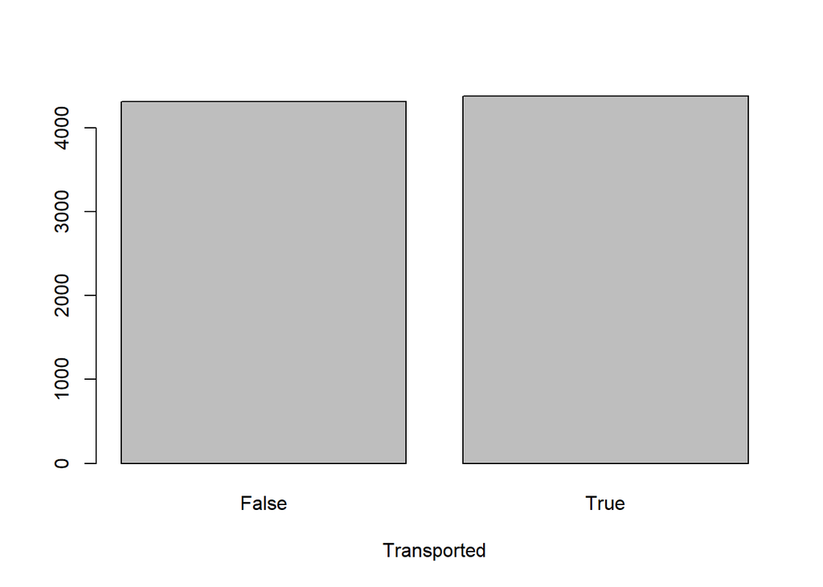

```r
barplot(counts, mais="", xlab="Transported")
```

```r
dados$Transported = as.integer(dados$Transported == "True")
```

Valores de target equilibrados para verdadeiro e falso.

## One-hot encoding para HomePlanet, Destination, Cabin_Deck e Cabin_Side

```r
encoder = dummyVars(~ HomePlanet + Destination + Cabin_Deck + Cabin_Side, data=dados, sep="")
dadosEncoded = predict(encoder, newdata=dados)
dadosEncoded %>% head(3)
```

```
##   HomePlanetEarth HomePlanetEuropa HomePlanetMars DestinationC DestinationP
## 1               0                1              0            0            0
## 2               1                0              0            0            0
## 3               0                1              0            0            0
##   DestinationT Cabin_Deck Cabin_DeckA Cabin_DeckB Cabin_DeckC Cabin_DeckD
## 1            1          0           0           1           0           0
## 2            1          0           0           0           0           0
## 3            1          0           1           0           0           0
##   Cabin_DeckE Cabin_DeckF Cabin_DeckG Cabin_DeckT Cabin_Side Cabin_SidePort
## 1           0           0           0           0          0              1
## 2           0           1           0           0          0              0
## 3           0           0           0           0          0              0
##   Cabin_SideStarBoard
## 1                   0
## 2                   1
## 3                   1
```

```r
testEncoded = predict(encoder, newdata=test)
testEncoded %>% head(3)
```

```
##   HomePlanetEarth HomePlanetEuropa HomePlanetMars DestinationC DestinationP
## 1               1                0              0            0            0
## 2               1                0              0            0            0
## 3               0                1              0            1            0
##   DestinationT Cabin_Deck Cabin_DeckA Cabin_DeckB Cabin_DeckC Cabin_DeckD
## 1            1          0           0           0           0           0
## 2            1          0           0           0           0           0
## 3            0          0           0           0           1           0
##   Cabin_DeckE Cabin_DeckF Cabin_DeckG Cabin_DeckT Cabin_Side Cabin_SidePort
## 1           0           0           1           0          0              0
## 2           0           1           0           0          0              0
## 3           0           0           0           0          0              0
##   Cabin_SideStarBoard
## 1                   1
## 2                   1
## 3                   1
```

```r
# Concatenação das tabelas
dados = cbind(dados, dadosEncoded)
test = cbind(test, testEncoded)
```

## Remoção de colunas que não serão mais usadas

```r
dados = dados[, !colnames(dados) %in% c("HomePlanet", "Cabin_Deck", "Cabin_Side", "Destination", "Cabin_Num")]
test = test[, !colnames(test) %in% c("HomePlanet", "Cabin_Deck", "Cabin_Side", "Destination", "Cabin_Num")]
```

## Validação de nulos

```r
dadosComNulos = dados[!complete.cases(dados),]
head(dadosComNulos)
```

```
##  [1] CryoSleep           Age                 VIP
##  [4] RoomService         FoodCourt           ShoppingMall
##  [7] Spa                 VRDeck              Transported
## [10] PassengerId_Group   PassengerId_Num     HomePlanetEarth
## [13] HomePlanetEuropa    HomePlanetMars      DestinationC
## [16] DestinationP        DestinationT        Cabin_DeckA
## [19] Cabin_DeckB         Cabin_DeckC         Cabin_DeckD
## [22] Cabin_DeckE         Cabin_DeckF         Cabin_DeckG
## [25] Cabin_DeckT         Cabin_SidePort      Cabin_SideStarBoard
## <0 linhas> (ou row.names de comprimento 0)
```

Não existem mais registros com dados nulos.

## Matriz de Correlação

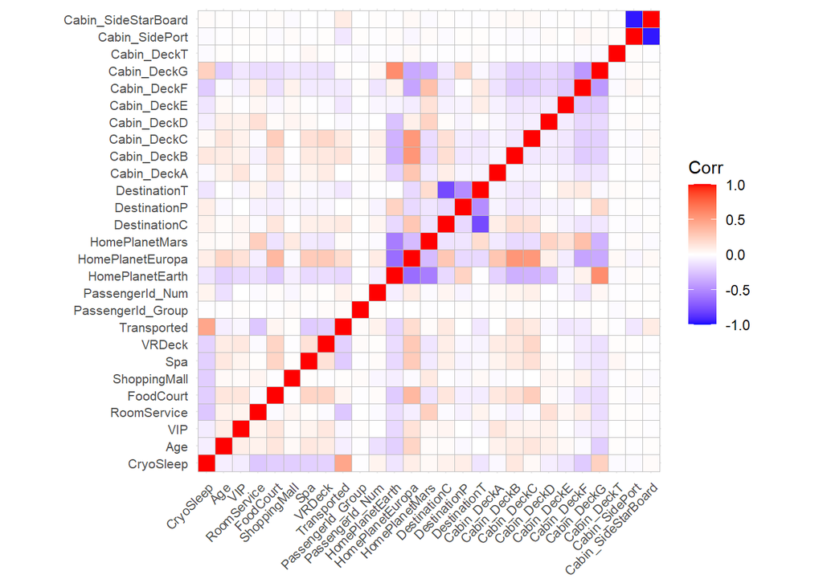

```r
corr = cor(dados)

options(repr.plot.width=25, repr.plot.height=25)
ggcorrplot(corr, tl.cex = 8)
```

Analisando a matriz, é possível verificar que os dados de Cabin_SideStarBoard e Cabin_SidePort não apresentam correção significativa com nenhuma outra coluna. O mesmo acontece com o PassengerId_Group, PassengerId_Num e Cabin_DeckT.

Além disso, é possível ver que algumas relações são mais contundentes para a variável target Transported. Para facilitar a visualização, as correlações mais altas identificadas visualmente serão quantificadas.

Algumas correlações que chamam a atenção no gráfico são facilmente entendíveis, já que, por exemplo, quando o destino é T, ele não é C, fazendo com que um seja a negação do outro.

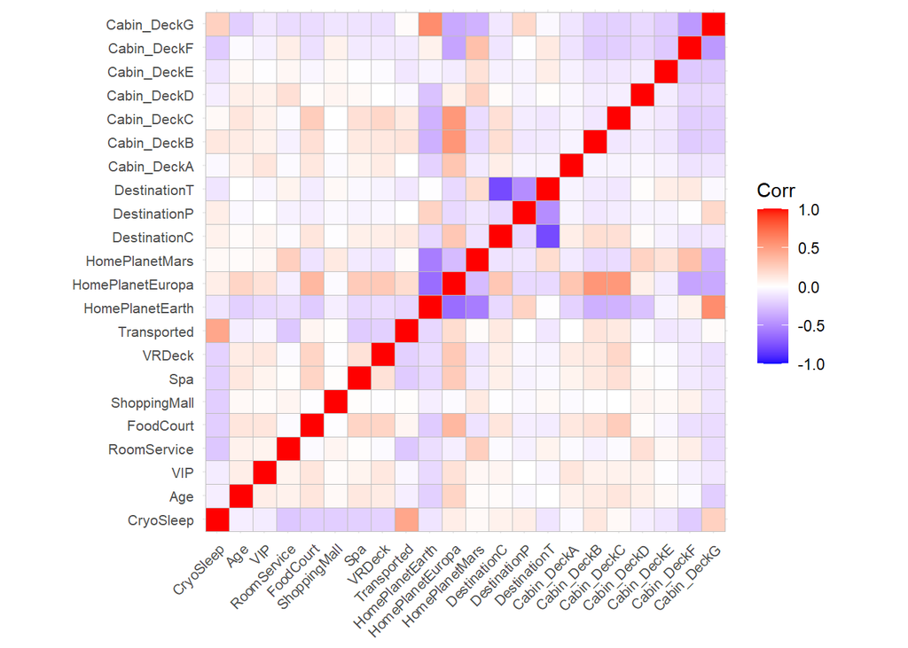

```r
#Por este motivo, essas 4 colunas serão descartadas para uma nova análise, especialmente com o target.

dados = dados[, !colnames(dados) %in% c("PassengerId_Group", "PassengerId_Num", "Cabin_DeckT", "Cabin_SideStarBoard", "Cabin_SidePort")]
test = test[, !colnames(test) %in% c("PassengerId_Group", "PassengerId_Num", "Cabin_DeckT", "Cabin_SideStarBoard", "Cabin_SidePort")]

corr = cor(dados)

options(repr.plot.width=25, repr.plot.height=25)
ggcorrplot(corr, tl.cex = 8)
```

Analisando novamente, é possível ver que algumas relações são mais contundentes para a variável target Transported. Para facilitar a visualização, as correlações mais altas identificadas visualmente serão quantificadas.

```r
cor(dados$CryoSleep, dados$Transported)
```

```
## [1] 0.4601324
```

```r
cor(dados$RoomService, dados$Transported)
```

```
## [1] -0.2411236
```

```r
cor(dados$Spa, dados$Transported)
```

```
## [1] -0.2185446
```

```r
cor(dados$VRDeck, dados$Transported)
```

```
## [1] -0.2048737
```

Ainda assim, as correlações são pouco significativas com a saída, sendo a maior entre Cryosleep, de 46%. Algumas correlações que chamam a atenção no gráfico são facilmente entendíveis, já que, por exemplo, quando o destino é T, ele não é C, fazendo com que um seja a negação do outro.

## Modelo com todas as colunas que permaneceram no df, sem padronização

```r
modelo1 <- glm(Transported ~ ., family = binomial, data = dados)
pred1 = avaliacao(modelo1, 0)
```

```
##
## Call:
## glm(formula = Transported ~ ., family = binomial, data = dados)
##
## Deviance Residuals:
##      Min        1Q    Median        3Q       Max
## -3.05413  -0.68666   0.04154   0.77767   3.12724
##
## Coefficients: (2 not defined because of singularities)
##                    Estimate Std. Error z value Pr(>|z|)
## (Intercept)       3.618e-01  2.184e-01   1.656  0.09770 .
## CryoSleep         1.325e+00  7.777e-02  17.032  < 2e-16 ***
## Age              -8.591e-03  2.035e-03  -4.221 2.43e-05 ***
## VIP              -3.343e-01  2.475e-01  -1.351  0.17671
## RoomService      -1.502e-03  9.080e-05 -16.537  < 2e-16 ***
## FoodCourt         4.966e-04  4.011e-05  12.381  < 2e-16 ***
## ShoppingMall      4.974e-04  6.524e-05   7.624 2.46e-14 ***
## Spa              -2.013e-03  1.045e-04 -19.262  < 2e-16 ***
## VRDeck           -1.927e-03  1.024e-04 -18.822  < 2e-16 ***
## HomePlanetEarth  -5.426e-01  9.103e-02  -5.961 2.51e-09 ***
## HomePlanetEuropa  1.047e+00  2.087e-01   5.020 5.17e-07 ***
## HomePlanetMars           NA         NA      NA       NA
## DestinationC      4.361e-01  7.973e-02   5.470 4.50e-08 ***
## DestinationP      1.660e-02  9.080e-02   0.183  0.85492
## DestinationT             NA         NA      NA       NA
## Cabin_DeckA      -4.576e-01  3.263e-01  -1.403  0.16072
## Cabin_DeckB       8.550e-01  3.061e-01   2.794  0.00521 **
## Cabin_DeckC       1.938e+00  3.313e-01   5.849 4.95e-09 ***
## Cabin_DeckD       1.626e-01  2.471e-01   0.658  0.51044
## Cabin_DeckE      -2.716e-01  2.126e-01  -1.278  0.20135
## Cabin_DeckF       3.123e-01  1.999e-01   1.562  0.11822
## Cabin_DeckG      -1.028e-01  2.003e-01  -0.513  0.60799
## ---
## Signif. codes:  0 '***' 0.001 '**' 0.01 '*' 0.05 '.' 0.1 ' ' 1
##
## (Dispersion parameter for binomial family taken to be 1)
##
##     Null deviance: 12050.6  on 8692  degrees of freedom
## Residual deviance:  7632.4  on 8673  degrees of freedom
## AIC: 7672.4
```

[output cut: 10 more lines]

```
##        1.5466805        1.0167415               NA        0.6327855
##      Cabin_DeckB      Cabin_DeckC      Cabin_DeckD      Cabin_DeckE
##        2.3513437        6.9432927        1.1765816        0.7621328
##      Cabin_DeckF      Cabin_DeckG
##        1.3664995        0.9023484
## Matriz de confusão:
## y.pred.class    0    1
##            0 3330  846
##            1  985 3532
## Predições corretas:  6862
## Predições incorretas:  1831
## Acurácia:  0.7893708
## Precisão:  0.7717265 0.8067611
## Recall:  0.7974138 0.7819349
## F1 Score:  0.7843599 0.794154
```

## Modelo somente com as features mais relacionadas ao target, sem padronização

```r
modelo2 <- glm(Transported ~ CryoSleep + RoomService + Spa + VRDeck, family = binomial, data = dados)
avaliacao(modelo2, 0)
```

```
##
## Call:
## glm(formula = Transported ~ CryoSleep + RoomService + Spa + VRDeck,
##     family = binomial, data = dados)
##
## Deviance Residuals:
##     Min       1Q   Median       3Q      Max
## -1.8447  -0.9134   0.6347   0.6347   3.6798
##
## Coefficients:
##               Estimate Std. Error z value Pr(>|z|)
## (Intercept)  1.509e-01  4.085e-02   3.694  0.00022 ***
## CryoSleep    1.349e+00  6.226e-02  21.670  < 2e-16 ***
## RoomService -1.366e-03  8.422e-05 -16.220  < 2e-16 ***
## Spa         -1.062e-03  8.007e-05 -13.266  < 2e-16 ***
## VRDeck      -8.538e-04  7.179e-05 -11.893  < 2e-16 ***
## ---
## Signif. codes:  0 '***' 0.001 '**' 0.01 '*' 0.05 '.' 0.1 ' ' 1
##
## (Dispersion parameter for binomial family taken to be 1)
##
##     Null deviance: 12050.6  on 8692  degrees of freedom
## Residual deviance:  9129.1  on 8688  degrees of freedom
## AIC: 9139.1
##
## Number of Fisher Scoring iterations: 6
##
## (Intercept)   CryoSleep RoomService         Spa      VRDeck
##   1.1628856   3.8541620   0.9986349   0.9989383   0.9991465
## Matriz de confusão:
## y.pred.class    0    1
##            0 3197  901
##            1 1118 3477
## Predições corretas:  6674
## Predições incorretas:  2019
## Acurácia:  0.7677442
## Precisão:  0.7409038 0.7941983
## Recall:  0.7801367 0.7566921
## F1 Score:  0.7600143 0.7749916
```

## Padronização (entre 0 e 1)

```r
preproc1 <- preProcess(dados[,], method=c("range"))

dadospad <- predict(preproc1, dados[,])

head(dadospad)
```

```
##   CryoSleep       Age VIP RoomService    FoodCourt ShoppingMall        Spa
## 1         0 0.4936709   0 0.000000000 0.0000000000  0.000000000 0.00000000
## 2         0 0.3037975   0 0.007608013 0.0003018817  0.001064192 0.02450018
## 3         0 0.7341772   1 0.003001326 0.1199476738  0.000000000 0.29966976
## 4         0 0.4177215   0 0.000000000 0.0430349177  0.015792610 0.14856301
## 5         0 0.2025316   0 0.021148880 0.0023479690  0.006427720 0.02521421
## 6         0 0.5569620   0 0.000000000 0.0162009861  0.000000000 0.01298643
##         VRDeck Transported HomePlanetEarth HomePlanetEuropa HomePlanetMars
## 1 0.000000e+00           0               0                1              0
## 2 1.823230e-03           1               1                0              0
## 3 2.030415e-03           0               0                1              0
## 4 7.997348e-03           0               0                1              0
## 5 8.287407e-05           1               1                0              0
## 6 0.000000e+00           1               1                0              0
##   DestinationC DestinationP DestinationT Cabin_DeckA Cabin_DeckB Cabin_DeckC
## 1            0            0            1           0           1           0
## 2            0            0            1           0           0           0
## 3            0            0            1           1           0           0
## 4            0            0            1           1           0           0
## 5            0            0            1           0           0           0
## 6            0            1            0           0           0           0
##   Cabin_DeckD Cabin_DeckE Cabin_DeckF Cabin_DeckG
## 1           0           0           0           0
## 2           0           0           1           0
## 3           0           0           0           0
## 4           0           0           0           0
## 5           0           0           1           0
## 6           0           0           1           0
```

## Modelo somente com todas as features, com padronização

```r
# Modelo somente com as features mais relacionadas ao target
modelo3 <- glm(Transported ~ ., family = binomial, data = dadospad)
avaliacao(modelo3, 0)
```

```
##
## Call:
## glm(formula = Transported ~ ., family = binomial, data = dadospad)
##
## Deviance Residuals:
##      Min        1Q    Median        3Q       Max
## -3.05413  -0.68666   0.04154   0.77767   3.12724
##
## Coefficients: (2 not defined because of singularities)
##                   Estimate Std. Error z value Pr(>|z|)
## (Intercept)        0.36178    0.21845   1.656  0.09770 .
## CryoSleep          1.32462    0.07777  17.032  < 2e-16 ***
## Age               -0.67871    0.16079  -4.221 2.43e-05 ***
## VIP               -0.33433    0.24747  -1.351  0.17671
## RoomService      -21.51263    1.30087 -16.537  < 2e-16 ***
## FoodCourt         14.80639    1.19586  12.381  < 2e-16 ***
## ShoppingMall      11.68497    1.53268   7.624 2.46e-14 ***
## Spa              -45.10924    2.34184 -19.262  < 2e-16 ***
## VRDeck           -46.49416    2.47017 -18.822  < 2e-16 ***
## HomePlanetEarth   -0.54259    0.09103  -5.961 2.51e-09 ***
## HomePlanetEuropa   1.04739    0.20865   5.020 5.17e-07 ***
## HomePlanetMars          NA         NA      NA       NA
## DestinationC       0.43611    0.07973   5.470 4.50e-08 ***
## DestinationP       0.01660    0.09080   0.183  0.85492
## DestinationT            NA         NA      NA       NA
## Cabin_DeckA       -0.45762    0.32625  -1.403  0.16072
## Cabin_DeckB        0.85499    0.30605   2.794  0.00521 **
## Cabin_DeckC        1.93778    0.33131   5.849 4.95e-09 ***
## Cabin_DeckD        0.16261    0.24708   0.658  0.51044
## Cabin_DeckE       -0.27163    0.21259  -1.278  0.20135
## Cabin_DeckF        0.31225    0.19987   1.562  0.11822
## Cabin_DeckG       -0.10275    0.20032  -0.513  0.60799
## ---
## Signif. codes:  0 '***' 0.001 '**' 0.01 '*' 0.05 '.' 0.1 ' ' 1
##
## (Dispersion parameter for binomial family taken to be 1)
##
##     Null deviance: 12050.6  on 8692  degrees of freedom
## Residual deviance:  7632.4  on 8673  degrees of freedom
## AIC: 7672.4
```

[output cut: 10 more lines]

```
##     1.546681e+00     1.016741e+00               NA     6.327855e-01
##      Cabin_DeckB      Cabin_DeckC      Cabin_DeckD      Cabin_DeckE
##     2.351344e+00     6.943293e+00     1.176582e+00     7.621328e-01
##      Cabin_DeckF      Cabin_DeckG
##     1.366500e+00     9.023484e-01
## Matriz de confusão:
## y.pred.class    0    1
##            0 3330  846
##            1  985 3532
## Predições corretas:  6862
## Predições incorretas:  1831
## Acurácia:  0.7893708
## Precisão:  0.7717265 0.8067611
## Recall:  0.7974138 0.7819349
## F1 Score:  0.7843599 0.794154
```

## Modelo somente com as features mais relacionadas ao target, com padronização

```r
# Modelo somente com as features mais relacionadas ao target
modelo4 <- glm(Transported ~ CryoSleep + RoomService + Spa + VRDeck, family = binomial, data = dadospad)
avaliacao(modelo4, 0)
```

```
##
## Call:
## glm(formula = Transported ~ CryoSleep + RoomService + Spa + VRDeck,
##     family = binomial, data = dadospad)
##
## Deviance Residuals:
##     Min       1Q   Median       3Q      Max
## -1.8447  -0.9134   0.6347   0.6347   3.6798
##
## Coefficients:
##              Estimate Std. Error z value Pr(>|z|)
## (Intercept)   0.15090    0.04085   3.694  0.00022 ***
## CryoSleep     1.34915    0.06226  21.670  < 2e-16 ***
## RoomService -19.57073    1.20658 -16.220  < 2e-16 ***
## Spa         -23.80231    1.79422 -13.266  < 2e-16 ***
## VRDeck      -20.60603    1.73256 -11.893  < 2e-16 ***
## ---
## Signif. codes:  0 '***' 0.001 '**' 0.01 '*' 0.05 '.' 0.1 ' ' 1
##
## (Dispersion parameter for binomial family taken to be 1)
##
##     Null deviance: 12050.6  on 8692  degrees of freedom
## Residual deviance:  9129.1  on 8688  degrees of freedom
## AIC: 9139.1
##
## Number of Fisher Scoring iterations: 6
##
##  (Intercept)    CryoSleep  RoomService          Spa       VRDeck
## 1.162886e+00 3.854162e+00 3.166222e-09 4.600328e-11 1.124387e-09
## Matriz de confusão:
## y.pred.class    0    1
##            0 3197  901
##            1 1118 3477
## Predições corretas:  6674
## Predições incorretas:  2019
## Acurácia:  0.7677442
## Precisão:  0.7409038 0.7941983
## Recall:  0.7801367 0.7566921
## F1 Score:  0.7600143 0.7749916
```

## Análise dos resultados

Foram desenvolvidos 4 modelos, sendo dois deles com todas as features da base e outros dois com somente as features mais relacionadas à variável dependente (Transported). Foram feitos, também, experimentos com as features escaladas (entre 0 e 1) e não escaladas, de forma que foi possível determinar o melhor modelo. Interessante notar que não foi percebida diferença alguma nas predições com as bases escalada e não escalada, demonstrando que, para este caso, não fez efeito.

## Predição na base de testes

```r
y.pred.prob.test <- predict(modelo1, newdata=test, type = "response")
y.pred.class.test <- ifelse(y.pred.prob.test > 0.5, "True", "False")
head(y.pred.class.test)
```

```
##       1       2       3       4       5       6
##  "True" "False"  "True"  "True"  "True"  "True"
```

## Salvamento do resultado (melhor modelo)

```r
test$Transported = y.pred.class.test
write.csv(test[, c("PassengerId","Transported")], "teste2.csv", row.names=FALSE, quote=FALSE)
```